# visStatistics: Automated selection and visualisation of statistical hypothesis tests in R

Sabine Schilling https://github.com/shhschilling/visStatistics (Institute of Tourism and Mobility, Lucerne University of Applied Sciences and Arts)  
2026-05-11

## 1 Introduction

Most routine data analyses reduce to a comparatively small set of inferential frameworks: group comparisons, contingency-table analyses, correlation, and simple regression (Sato et al. 2017; Chicco et al. 2025). Selecting the appropriate test within each framework, however, requires evaluating variable types, sample sizes, and distributional assumptions — a process that is error-prone, time-consuming, and a recurring bottleneck in statistical consulting (Bijlenga et al. 2017) and undergraduate teaching.

Several R packages address parts of this problem. compareGroups (Subirana et al. 2014) automates test choice via a per-group Shapiro–Wilk normality test and produces publication-ready descriptive tables, but its primary output is tabular rather than graphical, and assumption diagnostics are not displayed alongside results. ggstatsplot (Patil 2021) produces information-rich ggplot2-based (Wickham 2016) plots with embedded test results, but requires the user to select the appropriate plotting function for each data-type combination (e.g., `ggbetweenstats()` for group comparisons, `ggscatterstats()` for regression). rstatix (Kassambara 2025) provides a pipe-friendly framework for common tests with tidy output, and ggpubr (Kassambara 2026) adds statistical annotations to publication-ready plots; both leave test selection entirely to the user.

visStatistics takes a different approach: a single function `visstat(x, y)` accepts any combination of numeric and categorical vectors and resolves the full decision pipeline — test selection, execution, assumption checking, and visualisation — without any further input. Three design choices distinguish it from the packages above.

First, normality is assessed on the pooled residuals of a linear model `lm(y ~ x)`, following the general linear model (GLM) framework (Searle 1971), rather than per group. Group-wise testing is statistically less powerful and more likely to reject normality unnecessarily, pushing the analysis to non-parametric methods (Lumley et al. 2002). When heteroscedasticity is subsequently detected, group-wise normality diagnostics are shown additionally, since Welch’s methods use group-specific variance estimates.

Second, assumption diagnostics are always displayed, regardless of whether assumptions are met. This enables users to visually override the automated decision in individual cases, and supports the pedagogical goal of making assumption checking an integral part of the analysis rather than an afterthought.

Third, all tests use their default settings from base R functions, keeping the dependency footprint minimal and the decision tree transparent. The package does not wrap external statistical engines; the automated layer is purely in the routing logic.

## 2 Package overview

visStatistics is available on CRAN. The package accepts input in three equivalent forms:

```r
# Recommended form:
visstat(x, y)

# Formula interface:
visstat(y ~ x, data = dataframe)

# Backward-compatible form:
visstat(dataframe, "namey", "namex")
```

where `x` and `y` are vectors of class `"numeric"`, `"integer"`, or `"factor"`. The function returns an object of class `"visstat"` with `print()`, `summary()`, and `plot()` S3 methods, and optionally writes graphics to disk via Cairo (Urbanek and Horner 2025).

## 3 Decision logic

The significance level $\alpha = 1 - \texttt{conf.level}$ is user-controlled (default 0.95). Figure 1 gives a high-level overview of all implemented tests by input class; Figure 2 details the decision path for a numeric response and categorical predictor.

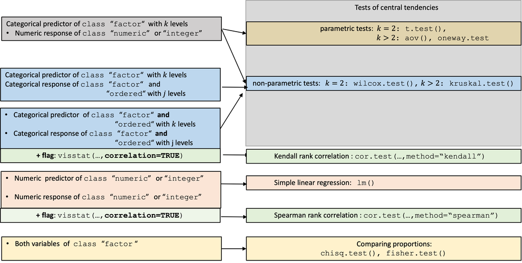

Figure 1: Overview of all implemented tests by input class.

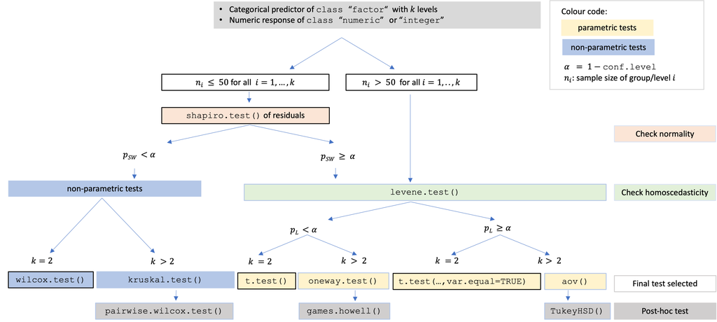

Figure 2: Decision tree for a numeric response and categorical predictor, based on sample size, normality of residuals, and homoscedasticity.

### 3.1 Numeric response and categorical predictor: comparing central tendencies

A linear model `lm(y ~ x)` is fitted and assumption diagnostics are always displayed via `vis_lm_assumptions()` (see Appendix A). The Shapiro–Wilk test (Shapiro and Wilk 1965) is applied to internally studentised residuals from `rstandard()` (Cook and Weisberg 1982). When all groups contain more than 50 observations, normality is assumed by the central limit theorem (Lumley et al. 2002; Rasch et al. 2011).

If normality is rejected ($p_\text{SW} \le \alpha$), non-parametric tests are selected: `wilcox.test()` (Mann and Whitney 1947) for two groups, or `kruskal.test()` (Kruskal and Wallis 1952) followed by Holm-adjusted `pairwise.wilcox.test()` (Holm 1979) for more than two groups.

If normality is not rejected, the Levene–Brown–Forsythe test `levene.test()` (Brown and Forsythe 1974) (see Appendix B) assesses variance homogeneity. For homoscedastic data, Student’s `t.test(var.equal = TRUE)` or Fisher’s `aov()` (Fisher and Yates 1990) with `TukeyHSD()` (Hochberg and Tamhane 1987) is applied. For heteroscedastic data, Welch’s `t.test()` (Satterthwaite 1946; Welch 1947) or `oneway.test()` (Welch 1951) with `games.howell()` (Games and Howell 1976) is applied. When switching to Welch methods, group-wise normality diagnostics are additionally displayed via `vis_group_normality()`, since the pooled `lm()` residuals are no longer the appropriate diagnostic under heteroscedasticity.

### 3.2 Both variables numeric: regression or rank correlation

By default, `visstat()` fits a simple linear regression via `lm()`, regardless of whether GLM assumptions are met, and always displays assumption diagnostics. When `correlation = TRUE` is set explicitly, Spearman’s $\rho$ is computed via `cor.test(..., method = "spearman")`. Because the choice between modelling a directional relationship and measuring a monotone association cannot be automated from data types alone, Spearman correlation is never triggered automatically.

### 3.3 Both variables categorical: comparing proportions

When both variables are categorical, `visstat()` tests independence using Pearson’s $\chi^2$ test (`chisq.test()`) or Fisher’s exact test (`fisher.test()`), depending on expected cell counts following Cochran’s rule (Cochran 1954): the $\chi^2$ approximation is used if no expected cell count is less than 1 and no more than 20% of cells have expected counts below 5. Yates’ continuity correction (Yates 1934) is applied by default to $2 \times 2$ tables. For general $R \times C$ tables, Pearson’s $\chi^2$ result is supplemented with a mosaic plot from vcd (Meyer et al. 2006, 2024) with tiles coloured by Pearson residuals.

### 3.4 Ordered factors

When the response is an ordered factor, `visstat()` converts it to integer level codes and follows the non-parametric path. When both variables are ordered and `correlation = TRUE`, Kendall’s $\tau_b$ (Kendall 1945; Agresti 2010) is computed instead, as it corrects for ties explicitly — unavoidable with few ordinal levels (Xu et al. 2013).

## 4 Implemented tests

### 4.1 Student’s t-test and Welch’s t-test

The test statistic for Student’s t-test is

$$\begin{equation}
t = \frac{\bar{x}_1 - \bar{x}_2}{s_p \sqrt{\frac{1}{n_1} + \frac{1}{n_2}}},
\quad s_p = \sqrt{\frac{(n_1-1)s_1^2 + (n_2-1)s_2^2}{n_1+n_2-2}},
\tag{1}
\end{equation}$$

following a $t$-distribution with $n_1 + n_2 - 2$ degrees of freedom. Welch’s t-test relaxes the homoscedasticity assumption:

$$\begin{equation}
t = \frac{\bar{x}_1 - \bar{x}_2}{\sqrt{s_1^2/n_1 + s_2^2/n_2}},
\tag{2}
\end{equation}$$

with degrees of freedom approximated by the Welch–Satterthwaite equation (Satterthwaite 1946; Welch 1947). Welch’s methods outperform their classical counterparts when variances differ (Moser and Stevens 1992; Fagerland and Sandvik 2009; Delacre et al. 2017).

```r
mtcars$am <- as.factor(mtcars$am)
t_test_stats <- visstat(mtcars$am, mtcars$mpg)
```

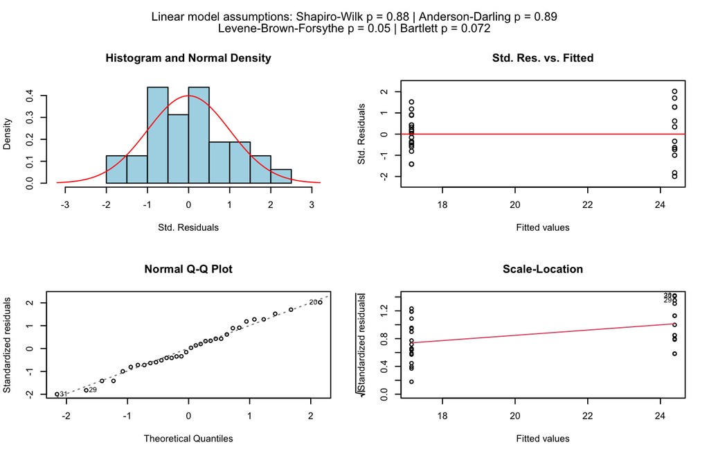

Figure 3: Welch’s t-test applied to the mtcars dataset. The assumption plot (left) and the group comparison (right) are both returned by visstat().

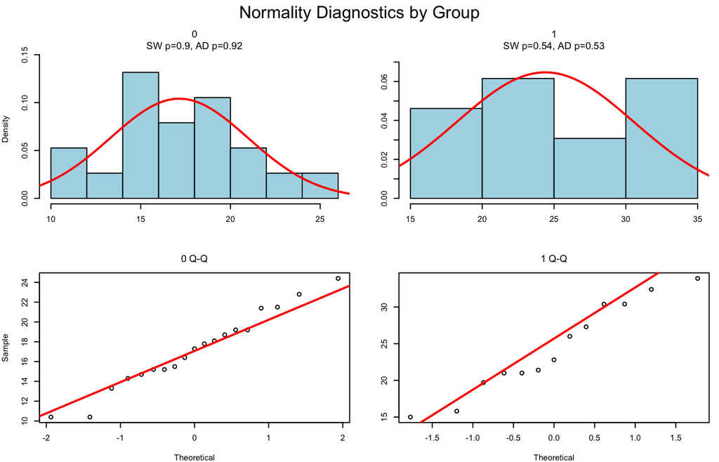

Figure 4: Welch’s t-test applied to the mtcars dataset. The assumption plot (left) and the group comparison (right) are both returned by visstat().

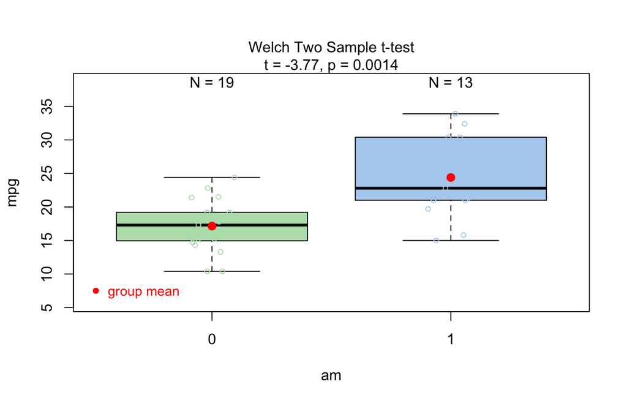

Figure 5: Welch’s t-test applied to the mtcars dataset. The assumption plot (left) and the group comparison (right) are both returned by visstat().

### 4.2 Wilcoxon rank-sum test

The test statistic is the Mann–Whitney $U$ statistic (Mann and Whitney 1947):

$$\begin{equation}
W = U_1 = W_1 - \frac{n_1(n_1+1)}{2},
\tag{3}
\end{equation}$$

where $W_1 = \sum_{i=1}^{n_1} R(x_{1,i})$ is the rank sum of the first group. An exact $p$-value is computed for samples of fewer than 50 observations without ties; otherwise a normal approximation with continuity correction is used.

### 4.3 Fisher’s one-way ANOVA and Welch’s heteroscedastic ANOVA

Fisher’s ANOVA test statistic is

$$\begin{equation}
F = \frac{SS_\text{between}/(k-1)}{SS_\text{within}/(N-k)},
\tag{4}
\end{equation}$$

following an $F(k-1, N-k)$ distribution. Post-hoc comparisons use `TukeyHSD()` (Hochberg and Tamhane 1987), which controls the family-wise error rate via the studentised range distribution (Abdi 2007).

Welch’s heteroscedastic ANOVA (`oneway.test()`) (Welch 1951) uses group-specific variance weights and a Satterthwaite-type adjustment for degrees of freedom. Post-hoc comparisons use `games.howell()` (Games and Howell 1976), which applies separate variance estimates per pair. Compact letter displays are produced by `multcompLetters()` from multcompView (Graves et al. 2026).

```r
anova_npk <- visstat(npk$block, npk$yield, conf.level = 0.95)
```

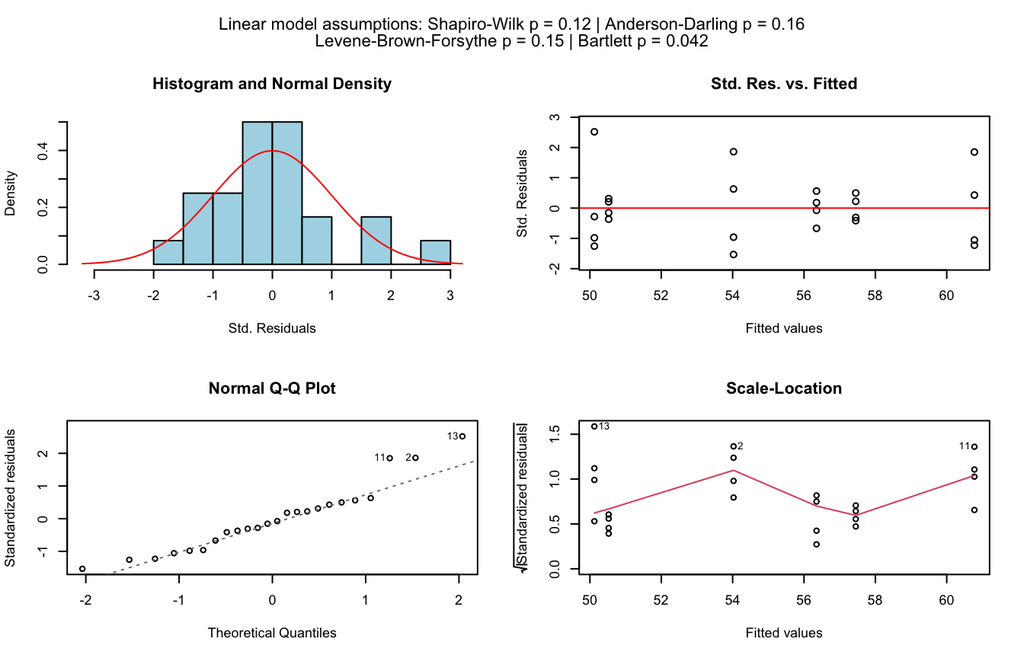

Figure 6: Fisher’s one-way ANOVA applied to the npk dataset. Green letters below the boxes indicate groups not significantly different after TukeyHSD correction.

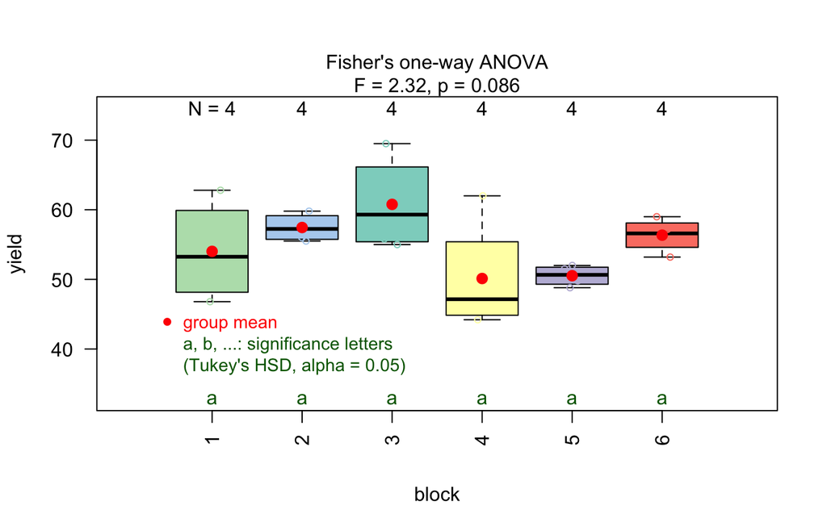

Figure 7: Fisher’s one-way ANOVA applied to the npk dataset. Green letters below the boxes indicate groups not significantly different after TukeyHSD correction.

### 4.4 Kruskal–Wallis test

When normality is rejected, `kruskal.test()` (Kruskal and Wallis 1952) tests whether the groups come from the same population based on ranks:

$$\begin{equation}
H = \frac{12}{N(N+1)} \sum_{i=1}^{k} n_i \left(\bar{R}_i - \bar{R}\right)^2,
\tag{5}
\end{equation}$$

approximately $\chi^2(k-1)$ under the null. Post-hoc comparisons use Holm-adjusted `pairwise.wilcox.test()` (Holm 1979).

### 4.5 Simple linear regression and Spearman rank correlation

The regression plot displays the fitted line $\hat{y} = b_0 + b_1 x$ with pointwise confidence and prediction bands at the specified `conf.level`. Assumption diagnostics always include the Shapiro–Wilk and Anderson–Darling (Gross and Ligges 2015) tests for residual normality and the Breusch–Pagan test `bp.test()` (Breusch and Pagan 1979) for homoscedasticity (see Appendix B).

```r
linreg_trees <- visstat(trees$Girth, trees$Volume, conf.level = 0.9)
```

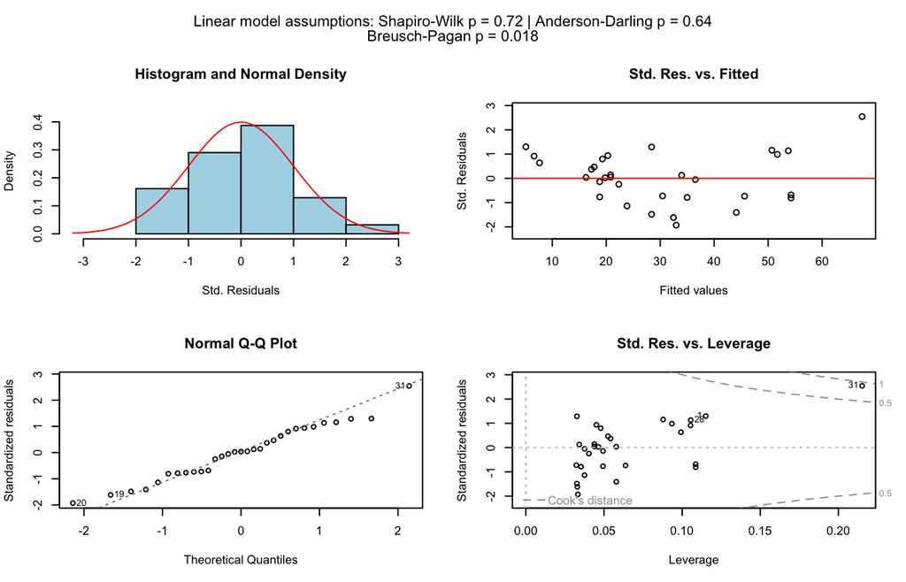

Figure 8: Simple linear regression of Volume on Girth for the trees dataset at conf.level = 0.9, with confidence band (dark) and prediction band (light).

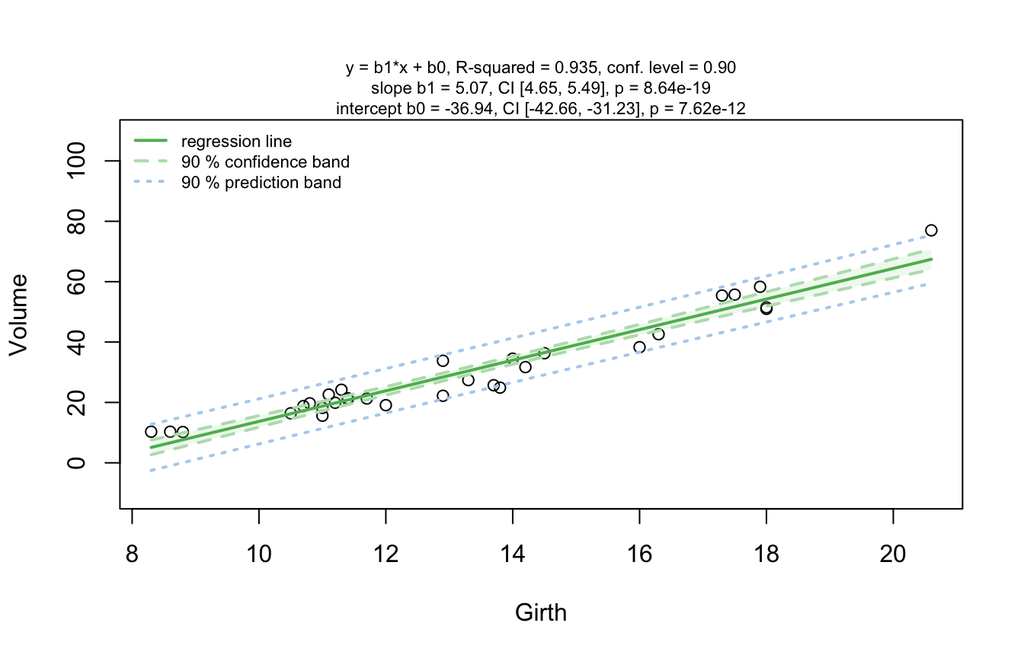

Figure 9: Simple linear regression of Volume on Girth for the trees dataset at conf.level = 0.9, with confidence band (dark) and prediction band (light).

When `correlation = TRUE`, Spearman’s $\rho$ is computed as Pearson’s $r$ applied to the ranks:

$$\begin{equation}
\rho = r\!\left(\operatorname{rank}(x),\, \operatorname{rank}(y)\right).
\tag{6}
\end{equation}$$

### 4.6 Pearson’s $\chi^2$ test and Fisher’s exact test

Let $O_{ij}$ and $E_{ij}$ denote the observed and expected frequencies in row $i$ and column $j$ of an $R \times C$ contingency table. The Pearson residual for cell $(i,j)$ is

$$\begin{equation}
r_{ij} = \frac{O_{ij} - E_{ij}}{\sqrt{E_{ij}}}.
\tag{7}
\end{equation}$$

The test statistic of Pearson’s $\chi^2$ test (Pearson 1900) is

$$\begin{equation}
\chi^2 = \sum_{i,j} r_{ij}^2,
\tag{8}
\end{equation}$$

compared to $\chi^2\!\left((R-1)(C-1)\right)$. For general $R \times C$ tables, `visstat()` supplements the bar chart with a mosaic plot in which tiles are coloured by $r_{ij}$ (blue: positive, red: negative), making the cells driving the association immediately visible.

Fisher’s exact test (Fisher 1970) is applied when Cochran’s rule (Cochran 1954) is violated. It evaluates the exact hypergeometric probability of the observed table given the fixed margins.

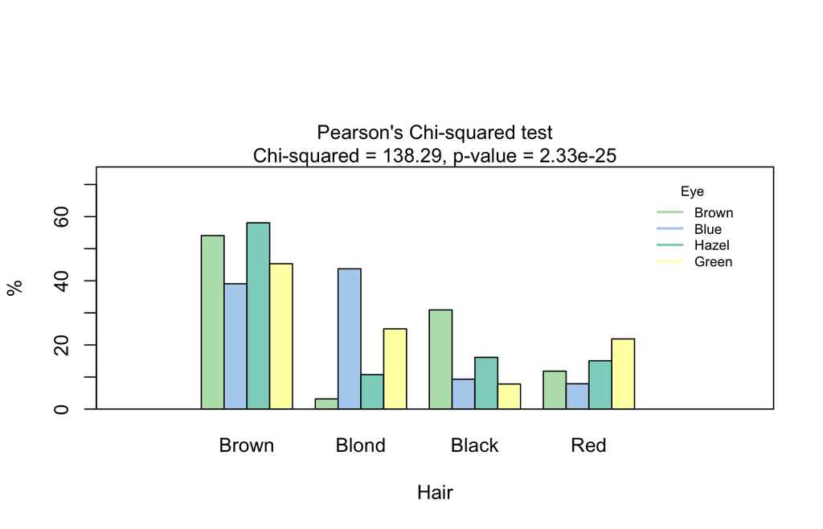

Figure 10: Pearson’s chi-squared test applied to the HairEyeColor dataset. The bar chart (left) shows row percentages; the mosaic plot (right) shows Pearson residuals colour-coded by vcd.

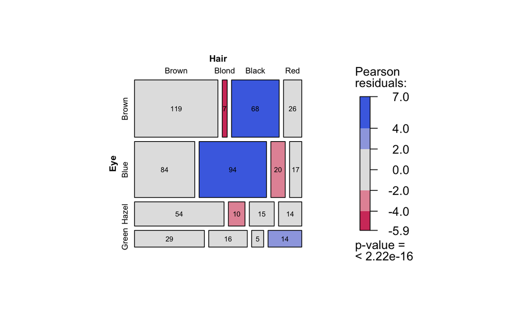

Figure 11: Pearson’s chi-squared test applied to the HairEyeColor dataset. The bar chart (left) shows row percentages; the mosaic plot (right) shows Pearson residuals colour-coded by vcd.

```r
hair_eye_df <- counts_to_cases(as.data.frame(HairEyeColor))
visstat(hair_eye_df$Eye, hair_eye_df$Hair)
```

### 4.7 Kendall’s $\tau_b$

For two ordinal variables with $n$ joint observations, Kendall’s $\tau_b$ (Kendall 1945) is

$$\begin{equation}
\tau_b = \frac{C - D}{\sqrt{(n_0 - n_1)(n_0 - n_2)}},
\tag{9}
\end{equation}$$

where $C$ and $D$ are the numbers of concordant and discordant pairs, $n_0 = n(n-1)/2$, and $n_1$, $n_2$ correct for ties in the response and predictor respectively. Kendall’s $\tau_b$ is preferred over Spearman’s $\rho$ for ordinal data with few levels, where ties are common (Agresti 2010; Xu et al. 2013).

## 5 Saving graphical output

All plots can be saved in any format supported by Cairo (Urbanek and Horner 2025) — `"png"`, `"pdf"`, `"svg"`, `"ps"`, `"tiff"` — by supplying the `graphicsoutput` and `plotDirectory` arguments. File names follow the pattern `testname_namey_namex.ext` by default, or a user-supplied `plotName`. The full file paths of generated graphics are stored as the `"plot_paths"` attribute on the returned `"visstat"` object.

## 6 Limitations

### 6.1 Scope of automated test selection

All tests are applied with their default settings from base R. As a consequence, paired tests are not supported and interaction terms are not available in the ANOVA path. Only simple linear regression is implemented, as multiple regression cannot be visualised in two dimensions. When regression assumptions are violated, visStatistics offers Spearman rank correlation (`correlation = TRUE`) as the sole automated alternative. Alternative methods such as data transformations, generalised linear models, or robust regression are not implemented: each requires user judgment — about the transformation family, the link function, or the estimator — that cannot be automated without substantially expanding the decision tree and increasing the risk of Type I error inflation.

### 6.2 P-value-based assumption testing

No single test maintains optimal Type I error rates and power across all distributions (Olejnik and Algina 1987). Normality tests behave poorly at both extremes of the sample-size range: they fail to detect non-normality in small samples and flag negligible departures as significant in large ones (Fagerland 2012; Ghasemi and Zahediasl 2012). The $n > 50$ per-group threshold for bypassing the Shapiro–Wilk test is necessarily arbitrary; simulation studies indicate that the required sample size for the central limit theorem to take effect depends on the skewness and kurtosis of the underlying distribution (Fagerland 2012). Assumption tests provide no information on the nature of the deviation (Shatz 2024), and combining multiple tests inflates the overall Type I error rate. For these reasons, the diagnostic plots generated by `visstat()` should always be inspected alongside the automated decision; the `conf.level` argument provides a direct handle on the $\alpha$ used throughout.

### 6.3 Visualisation

The package depends exclusively on base R graphics with no ggplot2 (Wickham 2016) dependency, keeping the transitive dependency footprint minimal. For more polished, annotated plots of chosen statistical tests, see ggstatsplot (Patil 2021) or ggpubr (Kassambara 2026).

## 7 Summary

visStatistics provides a single-function interface to automated statistical test selection, execution, and visualisation for the most commonly used inferential frameworks in two-variable analyses. Its principal contribution is the integration of the full pipeline — data-type detection, distributional assumption checking on GLM residuals, test routing, and annotated graphical output — into a reproducible, server-deployable workflow with a minimal dependency footprint. The package is available on CRAN at `https://CRAN.R-project.org/package=visStatistics` and on GitHub at `https://github.com/shhschilling/visStatistics`.

## 8 Appendix A: The general linear model

The general linear model (Searle 1971) provides a unified framework underlying Student’s t-test, Fisher’s ANOVA, and simple linear regression:

$$\begin{equation}
Y_i = \beta_0 + \beta_1 x_{i1} + \cdots + \beta_{k-1} x_{i,k-1} + \varepsilon_i,
\quad \varepsilon_i \sim N(0, \sigma^2).
\tag{10}
\end{equation}$$

**Student’s t-test** uses one binary indicator variable $x_{i1}$; testing $H_0: \beta_1 = 0$ is equivalent to testing $H_0: \mu_1 = \mu_2$.

**Fisher’s ANOVA** uses $k-1$ indicator variables for $k$ groups; testing $H_0: \beta_1 = \cdots = \beta_{k-1} = 0$ is equivalent to testing equality of all group means.

**Simple linear regression** uses one continuous predictor; testing $H_0: \beta_1 = 0$ examines whether a linear relationship exists.

The two-sample case connects t-tests and ANOVA: $t^2 = F$. For two groups, `t.test(var.equal = TRUE)` and `aov()` yield identical $p$-values, as do `t.test(var.equal = FALSE)` and `oneway.test()`.

## 9 Appendix B: Tests for homoscedasticity

### 9.1 The Levene–Brown–Forsythe test `levene.test()`

The test (Brown and Forsythe 1974) evaluates equality of variances using the absolute deviations from group medians $z_{ij} = |y_{ij} - \tilde{y}_i|$ and applies a one-way ANOVA $F$-statistic to the $z_{ij}$. Using the median rather than the mean makes it robust to skewed data (Allingham and Rayner 2012). The implementation `levene.test()` mimics the default behaviour of `leveneTest()` in car (Fox and Weisberg 2019) and drives the parametric/Welch branching decision.

### 9.2 Bartlett’s test `bartlett.test()`

Bartlett’s test (Bartlett 1937) has greater power than the Brown–Forsythe version when normality holds (Allingham and Rayner 2012). Its statistic

$$\begin{equation}
K^2 = \frac{(N-k)\ln s_p^2 - \sum_{i=1}^k (n_i-1)\ln s_i^2}
{1 + \frac{1}{3(k-1)}\!\left(\sum_{i=1}^k \frac{1}{n_i-1} - \frac{1}{N-k}\right)}
\tag{11}
\end{equation}$$

follows $\chi^2(k-1)$ under the null. Bartlett’s test result is shown in the assumption plot but does **not** drive the branching decision; only `levene.test()` does.

### 9.3 Breusch–Pagan test `bp.test()`

For simple linear regression, group-based variance tests are not applicable. The Breusch–Pagan test (Breusch and Pagan 1979) assesses whether the variance of the residuals depends on the predictor values and is shown in the regression assumption plot.

### 9.4 CRAN packages used

visStatistics, compareGroups, ggstatsplot, ggplot2, rstatix, ggpubr, Cairo, vcd, multcompView, car

### 9.5 CRAN Task Views implied by cited packages

ChemPhys, Econometrics, Finance, MixedModels, NetworkAnalysis, Phylogenetics, Spatial, TeachingStatistics

H. Abdi. The Bonferonni and Šidák Corrections for Multiple Comparisons. *Encyclopedia of measurement and statistics*, 2007.

A. Agresti. *Analysis of Ordinal Categorical Data.* 1st ed Wiley, 2010. DOI 10.1002/9780470594001.

D. Allingham and J. C. W. Rayner. Testing Equality of Variances for Multiple Univariate Normal Populations. *Journal of Statistical Theory and Practice*, 6(3): 524–535, 2012. DOI 10.1080/15598608.2012.695703.

M. S. Bartlett. Properties of sufficiency and statistical tests. *Proceedings of the Royal Society of London. Series A, Mathematical and Physical Sciences*, 160(901): 268–282, 1937. DOI 10.1098/rspa.1937.0109.

P. Bijlenga, R. Gondar, S. Schilling, S. Morel, S. Hirsch, J. Cuony, M.-V. Corniola, F. Perren, D. Rüfenacht and K. Schaller. PHASES Score for the Management of Intracranial Aneurysm: A Cross-Sectional Population-Based Retrospective Study. *Stroke*, 48(8): 2105–2112, 2017. DOI 10.1161/STROKEAHA.117.017391.

T. S. Breusch and A. R. Pagan. A Simple Test for Heteroscedasticity and Random Coefficient Variation. *Econometrica*, 47(5): 1287–1294, 1979. URL https://www.jstor.org/stable/1911963 [online; last accessed December 29, 2025].

M. B. Brown and A. B. Forsythe. Robust Tests for the Equality of Variances. *Journal of the American Statistical Association*, 69(346): 364–367, 1974. DOI 10.1080/01621459.1974.10482955.

D. Chicco, A. Sichenze and G. Jurman. A simple guide to the use of Student’s t-test, Mann-Whitney U test, Chi-squared test, and Kruskal-Wallis test in biostatistics. *BioData Min*, 18(1): 56, 2025. DOI 10.1186/s13040-025-00465-6.

W. G. Cochran. The Combination of Estimates from Different Experiments. *Biometrics*, 10(1): 101, 1954. URL https://www.jstor.org/stable/3001666 [online; last accessed May 19, 2025].

R. D. Cook and S. Weisberg. *Residuals and Influence in Regression.* New York: Chapman and Hall, 1982.

M. Delacre, D. Lakens and C. Leys. Why psychologists should by default use Welch’s t-test instead of Student’s t-test. *International Review of Social Psychology*, 30(1): 92–101, 2017. DOI 10.5334/irsp.82.

M. W. Fagerland. T-tests, non-parametric tests, and large studies—a paradox of statistical practice? *BMC Medical Research Methodology*, 12(1): 78, 2012. DOI 10.1186/1471-2288-12-78.

M. W. Fagerland and L. Sandvik. Performance of five two-sample location tests for skewed distributions with unequal variances. *Contemporary Clinical Trials*, 30(5): 490–496, 2009. DOI 10.1016/j.cct.2009.06.007.

R. A. Fisher. *Statistical methods for research workers.* 14th ed., revised and enlarged Edinburgh: Oliver and Boyd, 1970.

R. A. Fisher and F. Yates. *Statistical Methods, Experimental Design, and Scientific Inference: A Re-issue of Statistical Methods for Research Workers, the Design of Experiments and Statistical Methods and Scientific Inference.* Oxford University PressOxford, 1990. DOI 10.1093/oso/9780198522294.001.0001.

J. Fox and S. Weisberg. *An R companion to applied regression.* 3rd ed Thousand Oaks CA: Sage, 2019.

P. A. Games and J. F. Howell. Pairwise multiple comparison procedures with unequal N’s and/or variances: A Monte Carlo study. *Journal of Educational Statistics*, 1(2): 113–125, 1976. DOI 10.2307/1164979.

A. Ghasemi and S. Zahediasl. Normality Tests for Statistical Analysis: A Guide for Non-Statisticians. *Int J Endocrinol Metab*, 10(2): 486–489, 2012. DOI 10.5812/ijem.3505.

S. Graves, H.-P. Piepho and L. S. with help from Sundar Dorai-Raj. *multcompView: Visualizations of paired comparisons.* 2026. DOI 10.32614/CRAN.package.multcompView.

J. Gross and U. Ligges. *Nortest: Tests for normality.* 2015. DOI 10.32614/CRAN.package.nortest.

Y. Hochberg and A. C. Tamhane. *Multiple Comparison Procedures.* 1st ed Wiley, 1987. DOI 10.1002/9780470316672.

S. Holm. A Simple Sequentially Rejective Multiple Test Procedure. *Scandinavian Journal of Statistics*, 6(2): 65–70, 1979. URL https://www.jstor.org/stable/4615733 [online; last accessed May 19, 2025].

A. Kassambara. *Ggpubr: ’ggplot2’ based publication ready plots.* 2026. DOI 10.32614/CRAN.package.ggpubr.

A. Kassambara. *Rstatix: Pipe-friendly framework for basic statistical tests.* 2025. DOI 10.32614/CRAN.package.rstatix.

M. G. Kendall. The Treatment of Ties in Ranking Problems. *Biometrika*, 33(3): 239–251, 1945. URL https://www.jstor.org/stable/2332303 [online; last accessed May 9, 2026].

W. H. Kruskal and W. A. Wallis. Use of Ranks in One-Criterion Variance Analysis. *Journal of the American Statistical Association*, 47(260): 583–621, 1952. URL https://www.jstor.org/stable/2280779 [online; last accessed May 19, 2025].

T. Lumley, P. Diehr, S. Emerson and L. Chen. The Importance of the Normality Assumption in Large Public Health Data Sets. *Annu. Rev. Public Health*, 23(1): 151–169, 2002. DOI 10.1146/annurev.publhealth.23.100901.140546.

H. B. Mann and D. R. Whitney. On a test of whether one of two random variables is stochastically larger than the other. *The Annals of Mathematical Statistics*, 18(1): 50–60, 1947. DOI 10.1214/aoms/1177730491.

D. Meyer, A. Zeileis and K. Hornik. The strucplot framework: Visualizing multi-way contingency tables with vcd. *Journal of Statistical Software*, 17(3): 1–48, 2006. DOI 10.18637/jss.v017.i03.

D. Meyer, A. Zeileis, K. Hornik and M. Friendly. *vcd: Visualizing categorical data.* 2024. DOI 10.32614/CRAN.package.vcd.

B. K. Moser and G. R. Stevens. Homogeneity of variance in the two-sample means test. *The American Statistician*, 19–21, 1992. DOI 10.1080/00031305.1992.10475839.

S. F. Olejnik and J. Algina. Type I Error Rates and Power Estimates of Selected Parametric and Nonparametric Tests of Scale. *Journal of Educational Statistics*, 12(1): 45, 1987. URL https://www.jstor.org/stable/1164627 [online; last accessed June 17, 2025].

I. Patil. Visualizations with statistical details: The ’ggstatsplot’ approach. *Journal of Open Source Software*, 6(61): 3167, 2021. DOI 10.21105/joss.03167.

K. Pearson. On the criterion that a given system of deviations from the probable in the case of a correlated system of variables is such that it can be reasonably supposed to have arisen from random sampling. *The London, Edinburgh, and Dublin Philosophical Magazine and Journal of Science*, 50(302): 157–175, 1900. DOI 10.1080/14786440009463897.

D. Rasch, K. D. Kubinger and K. Moder. The two-sample t test: Pre-testing its assumptions does not pay off. *Stat Papers*, 52(1): 219–231, 2011. DOI 10.1007/s00362-009-0224-x.

Y. Sato, M. Gosho, K. Nagashima, S. Takahashi, J. H. Ware and N. M. Laird. Statistical methods in the ijournal/i &#x2014; an update. *New England Journal of Medicine*, 376(11): 1086–1087, 2017. DOI 10.1056/NEJMc1616211.

F. E. Satterthwaite. An Approximate Distribution of Estimates of Variance Components. *Biometrics Bulletin*, 2(6): 110–114, 1946. DOI 10.2307/3002019.

S. R. Searle. *Linear models.* John Wiley & Sons, 1971.

S. S. Shapiro and M. B. Wilk. An analysis of variance test for normality (complete samples). *Biometrika*, 52(3-4): 591–611, 1965. DOI 10.1093/biomet/52.3-4.591.

I. Shatz. Assumption-checking rather than (just) testing: The importance of visualization and effect size in statistical diagnostics. *Behav Res*, 56(2): 826–845, 2024. DOI 10.3758/s13428-023-02072-x.

I. Subirana, H. Sanz and J. Vila. Building bivariate tables: The compareGroups package for R. *Journal of Statistical Software*, 57(12): 1–16, 2014.

S. Urbanek and J. Horner. *Cairo: R graphics device using cairo graphics library for creating high-quality bitmap (PNG, JPEG, TIFF), vector (PDF, SVG, PostScript) and display (X11 and Win32) output.* 2025. DOI 10.32614/CRAN.package.Cairo.

B. L. Welch. On the Comparison of Several Mean Values: An Alternative Approach. *Biometrika*, 38(3/4): 330–336, 1951. URL https://www.jstor.org/stable/2332579 [online; last accessed May 20, 2025].

B. L. Welch. The generalization of “student’s” problem when several different population variances are involved. *Biometrika*, 34(1–2): 28–35, 1947. DOI 10.1093/biomet/34.1-2.28.

H. Wickham. *Ggplot2: Elegant graphics for data analysis.* Springer-Verlag New York, 2016.

W. Xu, Y. Hou, Y. S. Hung and Y. Zou. A comparative analysis of Spearman’s rho and Kendall’s tau in normal and contaminated normal models. *Signal Processing*, 93(1): 261–276, 2013. DOI 10.1016/j.sigpro.2012.08.005.

F. Yates. Contingency Tables Involving Small Numbers and the $\chi$2 Test. *Journal of the Royal Statistical Society Series B: Statistical Methodology*, 1(2): 217–235, 1934. DOI 10.2307/2983604.